# Aula 12

Mahayana Godoy

# Conteúdo do dia

# Conteúdo do dia

Nosso curso está se aproximando do fim e hoje faremos a revisão de alguns conteúdos. Nós iremos

- Entender o que um teste qui-quadrado faz, exatamente;
- Aprender a fazer gráficos de barras com mais informações do que vimos na última aula;
- Revisar os testes estatísticos que já vimos.

# Qui-quadrado

# Teste qui-quadrado

Vamos recuperar nosso conjunto de dados da última aula e refazer nossa tabela de contingência com a contagem de cada tipo de r. Vamos também fazer um teste qui-quadrado e salvá-lo com o nome “teste”.

```r
tabela = table(labov$r)
tabela
```

```
##
##  r0  r1
## 499 231
```

```r
teste = chisq.test(tabela)
```

# Teste qui-quadrado

A função `chisq.test()` retorna o resultado de um teste de hipóteses. Para entender de onde saiu esse resultado, vamos estudar os objetos usados pelo teste para fazer o teste de hipóteses.

Use a função `names()` para ver os objetos salvos nesse teste.

```r
names(teste)
```

```
## [1] "statistic" "parameter" "p.value"   "method"    "data.name" "observed"
## [7] "expected"  "residuals" "stdres"
```

O teste qui-quadrado calcula a probabilidade de um valor qui-quadrado dada $H_0$ (assim como um teste-t calcula a probabilidade de um valor t).

```r
teste$statistic
```

```
## X-squared
##  98.38904
```

# Teste qui-quadrado

Vamos ver o que há em “expected” e “observed”.

```r
teste$expected
```

```
##  r0  r1
## 365 365
```

```r
teste$observed
```

```
##
##  r0  r1
## 499 231
```

- O valor “observed” mostra os valores observados na nossa amostra.
- O valor em “expected” indica o valor esperado dada a $H_0$ (que, nesse caso, prevê que a distribuição seja igual entre as colunas).

# Qui-quadrado: cálculo

O teste faz um cálculo de quais seriam os valores observados entre dois grupos considerando a $H_0$.

Nesse caso, as duas colunas são rótico r0 e rótico r1.

O valor do qui-quadrado ($X^2$) é calculado de acordo com a seguinte fómula: $X^2$ = $\sum \frac{(O-E)^2}{E}$

No caso em mãos, temos o seguinte cálculo:

$\frac{(499-365)^2}{365} + \frac{(231-365)^2}{365}$ = $49.19452 + 49.19452$ = $98.38904$

# Qui-quadrado: cálculo

Rodando o teste novamente, vemos que esse é o valor de $X^2$ achado pelo teste:

```r
chisq.test(tabela)
```

```
##
##  Chi-squared test for given probabilities
##
## data:  tabela
## X-squared = 98.389, df = 1, p-value < 2.2e-16
```

# Qui-quadrado: distribuição de valores

Assim como *F* e *t*, a $X^2$ também é uma família de distribuições, e sua forma muda um pouco a depender dos seus graus de liberdade.

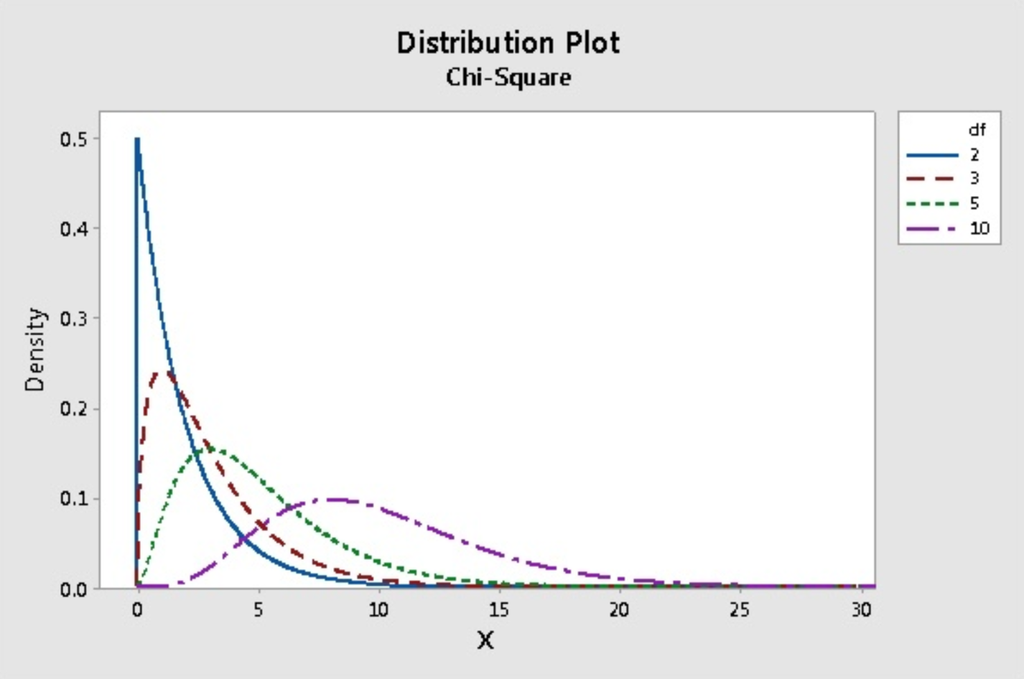

**Fonte:** http://blog.minitab.com/blog/statistics-and-quality-data-analysis/what-are-degrees-of-freedom-in-statistics

# Qui-quadrado: distribuição de valores

|  | Klein | Macys | Saks |
| --- | --- | --- | --- |
| r0 | 195 | 211 | 93 |
| r1 | 21 | 125 | 85 |

O grau de liberdade é determinado por (C-1)$*$(L-1); nesse caso:

$(3-1)*(2-1) = 2*1 = 2$

# Qui-quadrado: cálculo

Recuperemos a tabela com os dados da distribuição dos róticos por loja:

```r
tabela.lojas = table(labov$r, labov$store)
tabela.lojas
```

```
##
##      Klein Macys Saks
##   r0   195   211   93
##   r1    21   125   85
```

```r
chisq.test(tabela.lojas)
```

```
##
##  Pearson's Chi-squared test
##
## data:  tabela.lojas
## X-squared = 74.142, df = 2, p-value < 2.2e-16
```

Como previsto, o grau de liberdade aqui é 2.

# Qui-quadrado: cálculo

Vamos dar uma olhada nos valores observados e esperados dessa tabela

```r
teste.lojas = chisq.test(tabela.lojas)

teste.lojas$observed
```

```
##
##      Klein Macys Saks
##   r0   195   211   93
##   r1    21   125   85
```

```r
teste.lojas$expected
```

```
##
##          Klein    Macys      Saks
##   r0 147.64932 229.6767 121.67397
##   r1  68.35068 106.3233  56.32603
```

# Qui-quadrado: cálculo

Para entender o valor esperado, vamos ver uma tabela com os valores totais por linhas e colunas.

Valores Observados

|  | Klein | Macys | Saks | Sum |
| --- | --- | --- | --- | --- |
| r0 | 195 | 211 | 93 | 499 |
| r1 | 21 | 125 | 85 | 231 |
| Sum | 216 | 336 | 178 | 730 |

Valores Esperados

|  | Klein | Macys | Saks | Sum |
| --- | --- | --- | --- | --- |
| r0 | 147.64932 | 229.6767 | 121.67397 | 499 |
| r1 | 68.35068 | 106.3233 | 56.32603 | 231 |
| Sum | 216.00000 | 336.0000 | 178.00000 | 730 |

Podemos ver que a soma por linhas e colunas das duas tabelas é a mesma; ou seja, o teste calculou o valor esperado para r0 e r1 em cada loja considerando o valor total de róticos registrados por loja.

# Qui-quadrado: cálculo

De onde saíram esses valores esperados?

Valores Esperados

|  | Klein | Macys | Saks | Sum |
| --- | --- | --- | --- | --- |
| r0 | 147.64932 | 229.6767 | 121.67397 | 499 |
| r1 | 68.35068 | 106.3233 | 56.32603 | 231 |
| Sum | 216.00000 | 336.0000 | 178.00000 | 730 |

Na distribuição geral, independente de loja, tivemos ~ 68% de r0 e ~ 32% de r1. Fazendo uma conta na tabela acima, percebemos que:

- 147.64 é 68% de 216, e 68.35 é 32%
- 229.67 é 68% de 336, e 106.32 é 32%
- 121.67 é 68% de 178, e 56.32 é 32%

# Qui-quadrado: cálculo

A $H_0$ assumida para o cálculo dos valores esperados é o número de ocorrências que teríamos de r1 e r0 no caso de nossa variável independente (loja) *não* influenciar essa distribuição.

É importante saber disso para ter clareza do que o teste qui-quadrado está medindo.

# Qui-quadrado: cálculo

Considerando que o cálculo de $X^2$ é feito de acordo com a fórmula

$X^2$ = $\sum \frac{(O-E)^2}{E}$, podemos calcular esse valor com o R:

```r
O = teste.lojas$observed
E = teste.lojas$expected

x2 = sum((O-E)^2/E)
x2
```

```
## [1] 74.14189
```

# Qui-quadrado: cálculo

Esse é exatamente o valor que conseguimos com o teste:

```r
chisq.test(tabela.lojas)
```

```
##
##  Pearson's Chi-squared test
##
## data:  tabela.lojas
## X-squared = 74.142, df = 2, p-value < 2.2e-16
```

# Qui-quadrado: cálculo

É importante vermos que o cálculo do qui-quadrado é sensível à quantidade de dados coletados: quanto mais dados temos, maior a probabilidade de uma diferença ser significativa.

Vamos pegar nossa tabela e dividir por 20; isso diminui o número de observações

```r
tabela.lojas.20 = tabela.lojas/20
tabela.lojas.20
```

```
##
##      Klein Macys  Saks
##   r0  9.75 10.55  4.65
##   r1  1.05  6.25  4.25
```

# Qui-quadrado: cálculo

O *n* mudou, mas a proporção, não.

```r
prop.table(tabela.lojas, 2)
```

```
##
##           Klein      Macys       Saks
##   r0 0.90277778 0.62797619 0.52247191
##   r1 0.09722222 0.37202381 0.47752809
```

```r
prop.table(tabela.lojas.20, 2)
```

```
##
##           Klein      Macys       Saks
##   r0 0.90277778 0.62797619 0.52247191
##   r1 0.09722222 0.37202381 0.47752809
```

# Qui-quadrado: cálculo

Apesar de as probabilidades serem as mesmas, o resultado do texto qui-quadrado é diferente, pois o *n* é diferente.

```r
chisq.test(tabela.lojas)
```

```
##
##  Pearson's Chi-squared test
##
## data:  tabela.lojas
## X-squared = 74.142, df = 2, p-value < 2.2e-16
```

```r
chisq.test(tabela.lojas.20)
```

```
##
##  Pearson's Chi-squared test
##
## data:  tabela.lojas.20
## X-squared = 3.7071, df = 2, p-value = 0.1567
```

# Qui-quadrado: revisão

O qui-quadrado é um teste que:

-> Assume uma variável dependente categórica, e portanto pode ser usado para resultados de testes que podem ser modelados por uma distribuição binomial;

-> Assume uma variável independente categórica;

-> Calcula a probabilidade de um valor $X^2$ dada a $H_0$ segundo a qual a variável independente não influência a distribuição da variável dependente.

Devido à sua natureza, esse teste é muito comum em pesquisas de sociolinguística, especialmente quando queremos analisar se um contexto determina maior probabilidade de ocorrência de uma variante.

# Dados de contagem e proporção: visualização

# Barplot: revisão

Quando nossa variável dependente e independente são categóricas, a melhor maneira de mostrar diferenças entre os níveis da variável independente é através de um gráfico de barras.

Já vimos que a sintaxe para fazer um gráfico de barras com o ggplot não é difícil.

```r
ggplot(labov, aes(x=r))+ ## contagem
  geom_bar()


ggplot(labov, aes(x=r))+
  geom_bar(aes( y = (..count..)/sum(..count..))) + ## probabilidade
  scale_y_continuous(labels=scales::percent) ##porcentagem
```

# Barplot: comparação

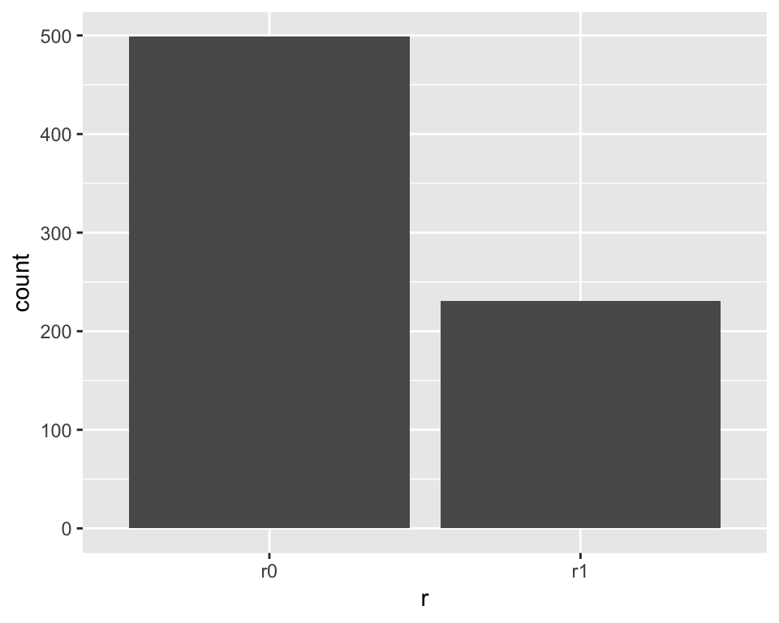

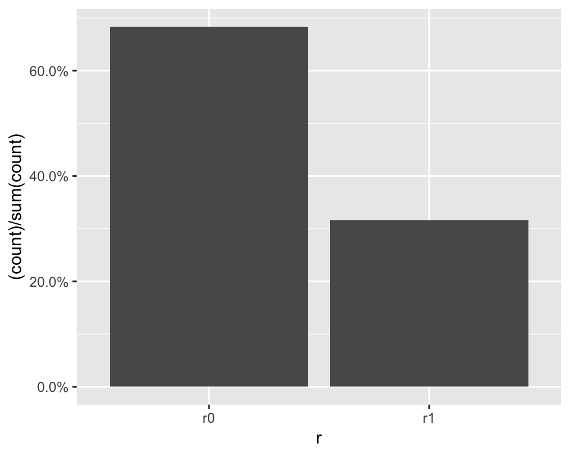

# Barplot: comparação

Se quiseremos fazer uma comparação por loja, o ideal é plotarmos as taxas de ocorrência de r0/r1 por loja. Há mais de uma maneira de fazer isso, mas todas partem desse código básico, que indica que o eixo x deve mostrar cada loja individualmente, e a barra deve mostrar a % de registros dessas lojas no valor total de registros.

```r
ggplot(labov, aes(x = store)) +
geom_bar(aes( y = (..count..)/sum(..count..))) +
scale_y_continuous(labels=scales::percent)+
labs(x = "Lojas", y = "%")
```

# Barplot: comparação

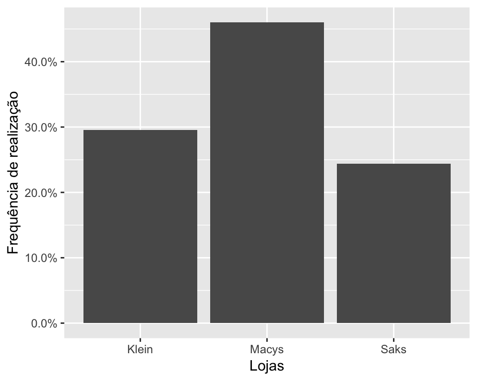

```r
ggplot(labov, aes(x = store)) +
geom_bar(aes( y = (..count..)/sum(..count..))) +
scale_y_continuous(labels=scales::percent)+
labs(x = "Lojas", y = "Frequência de realização")
```

# Barplot: comparações

Podemos mostrar a divisão entre r0 e r1 indicando que queremos que a coluna *r* seja usada para preencher as barras.

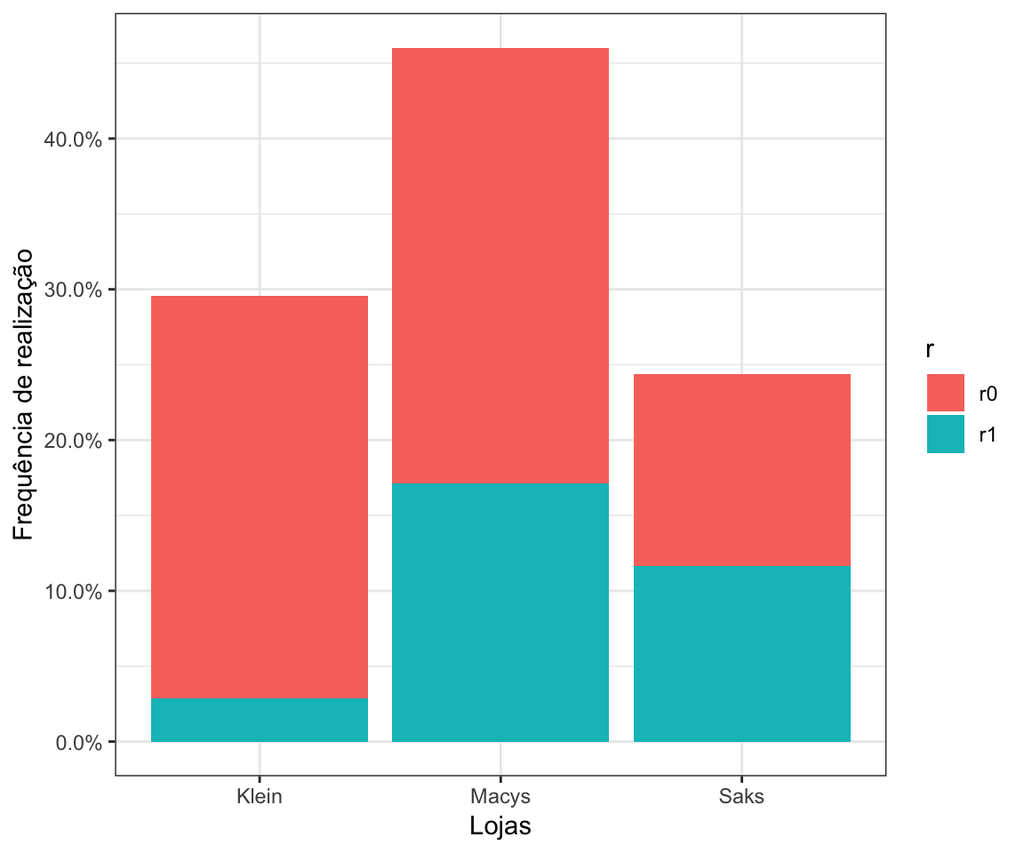

Basta dizer que você quer preencher (“fill”) a barra com os valores da coluna ‘r’. Veja a segunda linha.

```r
ggplot(labov, aes(x=store))+ ## probabilidade
  geom_bar(aes(y = ..count../sum(..count..), fill=r))+
  scale_y_continuous(labels=scales::percent)+ ## porcentagem
  labs(y = "Frequência de realização", x = "Lojas")+
  theme_bw()
```

# Barplot: comparações

Outra maneira é tomar cada loja individualmente (as ocorrências de cada uma somam 100%) ao plotar as taxas de ocorrência de cada tipo de r. Isso permite comparar de forma mais clara as diferenças entre as lojas.

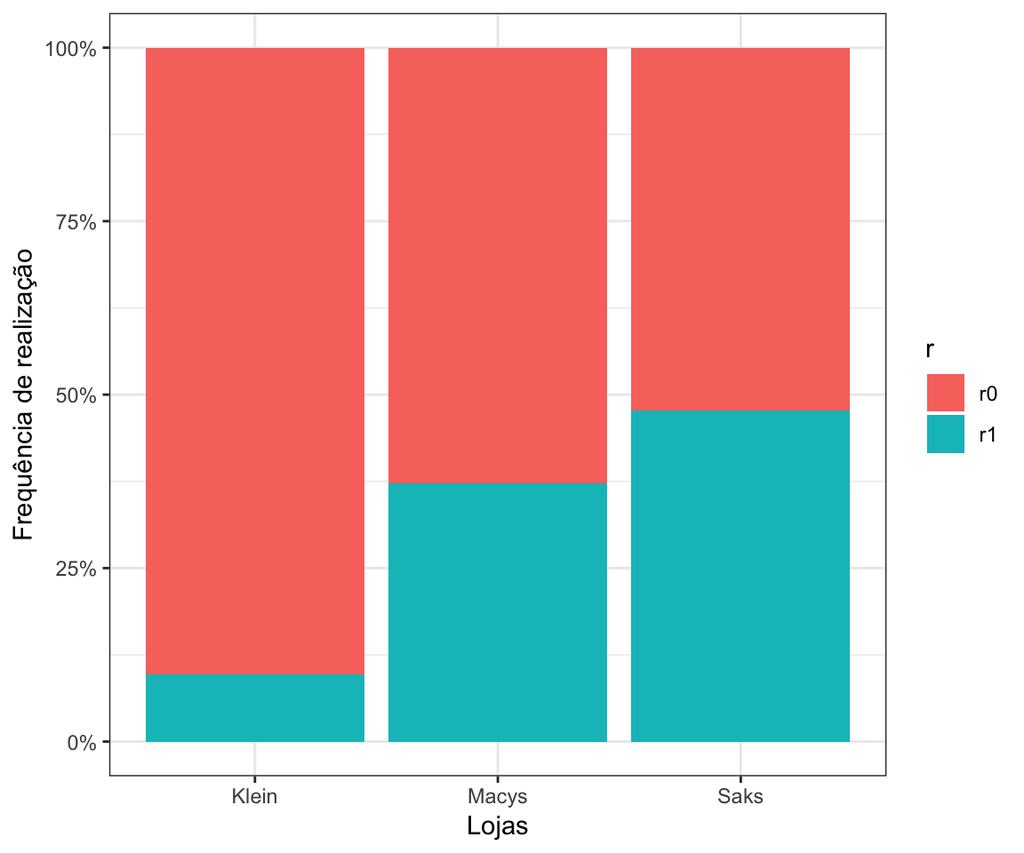

Veja as mudanças na primeira e segunda linhas. O porquê do código ser assim não faz muito sentido, o que é meio frustrante, mas agora você sabe como fazer!

```r
ggplot(labov, aes(x = store, fill = r)) +
  geom_bar(aes( y = (..count..)/sum(..count..)), position = "fill") +
  scale_y_continuous(labels=scales::percent)+
  labs(x = "Lojas", y = "Frequência de realização")+
  theme_bw()
```

# Barplot: comparações

O tipo de gráfico feito vai depender do que você quer mostrar.

Você provavelmente nunca lembrará toda essa sintaxe de memória, a menos que você faça **muitos** gráficos de barra.

O ideal é saber onde procurar esses códigos quando você precisar.

Você pode mudar as cores, as legendas e a ordem de apresentação nos gráficos. Não vamos conseguir cobrir tudo isso nesse curso, mas tem muito material bom na internet dando soluções para esses problemas.

# Revisão do curso

# Relembrando os testes estatísticos

Até o momento, vimos muitos testes estatísticos que podemos aplicar a diferentes tipos de conjuntos de dados a depender de suas variáveis dependentes, independentes e de suas distribuições.

Antes de seguir para o último tipo de teste estatístico que veremos - a regressão logística - vamos fazer uma pausa para testar nossos conhecimentos.

Dê uma olhada na tabela do slide seguinte.

# Relembrando os testes estatísticos

Você consegue preencher as lacunas dessa tabela?

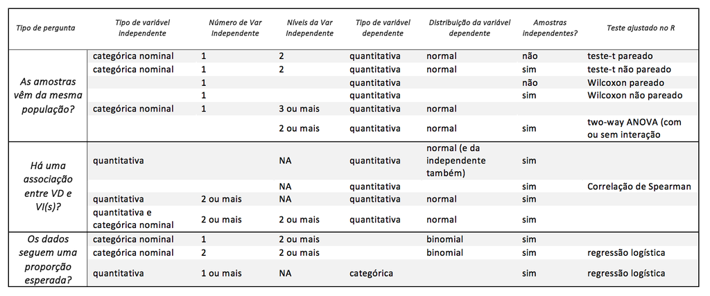

# Relembrando os testes estatísticos

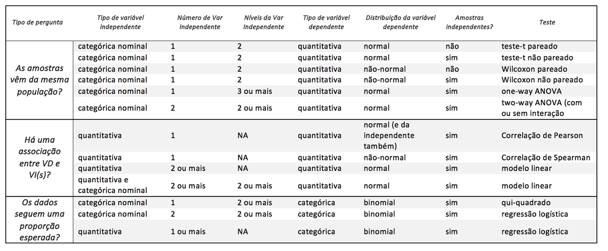

# Relembrando os testes estatísticos

A seguir, você verá uma série de problemas que podem ser resolvidos com os testes que estudamos até aqui. Tente respondê-los antes de ver as respostas

# Relembrando os testes estatísticos

Um professor da UFRN tem a hipótese de que os alunos dos cursos noturnos costumam ser mais velhos que os alunos do diurno. Para testar sua hipótese, ele seleciona uma amostra aleatória de 100 alunos do diurno e 100 alunos do noturno e anota suas idades. Que teste (ou testes) ele faria para testar sua hipótese? Escreva a $H_0$ e $H_A$ do professor.

- $H_0$: comparar média de idades, $\mu_\text{noturno}$ = $\mu_\text{diurno}$
- $H_A$: comparar média de idades, $\mu_\text{noturno}$ > $\mu_\text{diurno}$
- Teste a ser feito: Teste-t não-pareado se a distribuição dos dados de idade for normal, Wilcoxon não-pareado se não for normal
- Sintaxe no R: `t.test(x, y, paired = FALSE)` ou `wilcox.test(x, y, paired = FALSE)`

# Relembrando testes estatísticos

# Relembrando testes estatísticos

Uma pesquisadora acredita que o sucesso acadêmico de uma criança tem relação direta com os anos de estudos de seus pais. Para isso, ele seleciona uma amostra de 300 dados de uma prova feita por alunos que estão completando o Ensino Médio. Entre os dados, há a nota que o aluno tirou na prova e os anos de escolaridade dos pais (uma medida numérica que vai de 0 a 15). Que teste (ou testes) a pesquisadora faria para testar sua hipótese? Escreva a $H_0$ e $H_A$.

- $H_0$: r = 0 (não há correlação entre nota e escolaridade dos pais)
- $H_A$: r ≠ 0 (há correlação entre nota e escolaridade dos pais)
- Teste a ser feito: correlação de Spearman para dados não-normais e correlação de pearson para dados normais
- Sintaxe no R: `cor.test(x, y, method = spearman)` ou `cor.test(x,y)`

# Relembrando testes estatísticos

Nossa pesquisadora do Problema 3 apresentou seus dados em um artigo, mas um parecerista achou melhor que a escolaridade dos pais fosse dividida em três faixas: Faixa 1, de 0 a 5 anos, Faixa 2, de 6 a 10 anos, Faixa 3, de 11 a 15 anos. A exigência era de que a escolaridade fosse categorizada dentro de cada uma dessas faixas e fosse feito um novo teste. Que novo teste seria esse? Escreva a $H_0$ e $H_A$ para esse novo teste.

- $H_0$: $\mu_\text{Faixa1}$ = $\mu_\text{Faixa2}$ = $\mu_\text{Faixa3}$
- $H_A$: Ao menos uma $\mu$ entre as três faixas é diferente das demais
- Teste a ser feito: One-way ANOVA
- Sintaxe no R:
  - ajustar o modelo: `modelo = aov(nota~escolaridade, dados)`;
  - ver a Tabela ANOVA: `summary(modelo)`;
  - análise post-hoc: `Tukey(modelo)`.